# Day 27 Notes, Nov 6, 2013

# Today's topic: Hypothesis Testing

Two related concepts are needed:

1. Conditional Probability
2. Hypothetical Reasoning

## Conditional Probability and Bayes Rule

Mammography and breast cancer.

- Sensitivity is 90%
- Specificity is 90%

Let prevalence be 1%. If you have a positive mammogram, what's the probability of breast cancer.

### Bayes Rule in Algebraic Form

\[ p( condition | testres ) = \frac{p( testres | condition ) \times p(condition)}{p(testres)} \]

These parts of the expression have technical names:

- Likelihood: p( testres | condition )
- Evidence: p(testres | condition)/p(testres)
- Prior: p(condition)
- Posterior: p(condition|testres)

### Ivory-Billed Activity

Just the Bayesian Approach

## The Multi-World Metaphor for Statistical Inference

Motto: *Always know what world you are thinking about.*

[figure not shown]

We want to know which hypotheses are true on Earth and which are false.

The planets involved in statistical inference are:

Planet Sample

Planet Null

Planet Alt

[figure not shown]

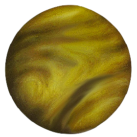

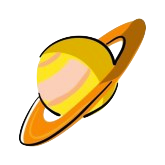

How to travel to the different worlds …

### Other hypotheses, with content

Side-by-side comparison: http://en.wikipedia.org/wiki/File:PileatedIvoryWoodpecker.svg

[Some of the photographic evidence](http://www.fishcrow.com/pearl29mar08.html) The Ivory Billed woodpecker from a hypothesis testing perspective second page.

How to travel to the different worlds …

- Planet Sample: resampling
- Planet Null: shuffling
- Planet Alt: You need to construct such a world (we'll pick this up in a few days)

We've already done several examples using resampling — the idea is to see how much sampling variation there would be if the world were just like our sample.

Now to do shuffling.

Work with model coefficients and \( R^2 \) from a few models, with shuffling of an explanatory variable, or shuffling of the response.

Example: Sector of the economy and wages

```r
mod = lm(wage ~ sector * sex + educ + exper, data = CPS85)
real = r.squared(mod)
real
```

```
## [1] 0.3113
```

Now go to Planet Null

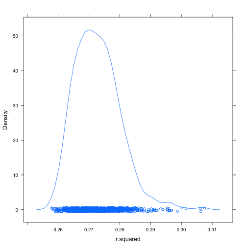

```r
s = do(1000) * lm(wage ~ shuffle(sector) * sex + educ + exper, data = CPS85)
densityplot(~r.squared, data = s)
```

```r
tally(~r.squared >= real, data = s)
```

```
##
##  TRUE FALSE Total
##     0  1000  1000
```

What's the p-value?

Do the same on a coefficient and look at the two-tailed test.

### Stocks on Planet Null

```r
fetchData("getDJIAdata.R")
```

```
## Retrieving from http://www.mosaic-web.org/go/datasets/getDJIAdata.R
```

```
## [1] TRUE
```

```r
djia = getDJIAdata()  # djia-2011.csv is the basic file
```

```
## Retrieving from http://www.mosaic-web.org/go/datasets/djia-2011.csv
```

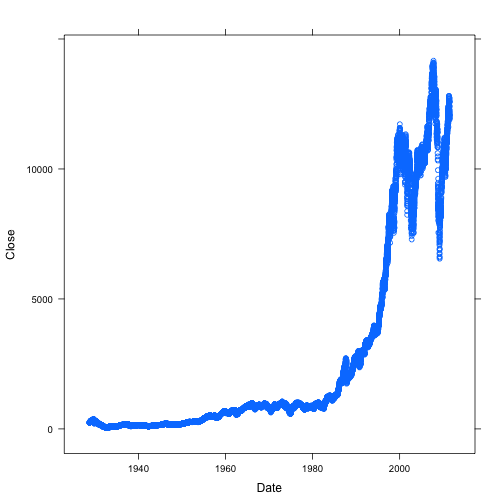

```r
xyplot(Close ~ Date, data = djia)
```

Look at the day-to-day differences in log prices:

```r
dd = with(djia, diff(log(Close)))
mean(dd)
```

```
## [1] 0.000191
```

Subtract out the mean, shuffle, cumulative sum, and exponentiate to create a realization:

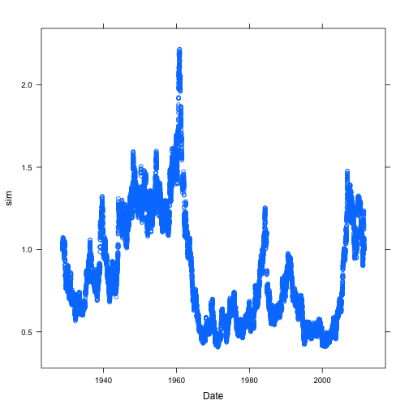

```r
ddnull = dd - mean(dd)
sim = exp(cumsum(shuffle(ddnull)))
xyplot(sim ~ Date, data = djia)
```

### Drunk Driving Example

Planet Null:

- Set up a roadblock, pull out the people who are not drunk. Measure their results.

Planet Alt

- Take the drunk people, measure their results.

What's the decision threshold?

### App for playing with Significance and Power

```r
fetchData("mHypTest.R")
mHypTest()  # by default, a coefficient
```